# NYPD Shooting Incident

1/26/2022

## Background:

This analysis is based on the “NYPD Shooting Incident Data(Historic)” from the website:https://catalog.data.gov/datase. The data lists all shooting incidents happened in NYC from 2006 to 2020, recorded the incident locations, the date and time of occurrence, the age group, race and gender of the victim. The dataset I am interested in finding the relationship between the gender&races of victims and the occurrence time in different locations.

```r
library(tidyverse)
library(lubridate)
library(readr)
url_in <- "https://data.cityofnewyork.us/api/views/833y-fsy8/rows.csv?accessType=DOWNLOAD"
```

```r
data <- read_csv(url_in)
head(data)
```

```
## # A tibble: 6 × 19
##   INCIDENT_KEY OCCUR_DATE OCCUR_TIME BORO     PRECINCT JURISDICTION_CODE
##          <dbl> <chr>      <time>     <chr>       <dbl>             <dbl>
## 1     24050482 08/27/2006 05:35      BRONX          52                 0
## 2     77673979 03/11/2011 12:03      QUEENS        106                 0
## 3    203350417 10/06/2019 01:09      BROOKLYN       77                 0
## 4     80584527 09/04/2011 03:35      BRONX          40                 0
## 5     90843766 05/27/2013 21:16      QUEENS        100                 0
## 6     92393427 09/01/2013 04:17      BROOKLYN       67                 0
## # … with 13 more variables: LOCATION_DESC <chr>, STATISTICAL_MURDER_FLAG <lgl>,
## #   PERP_AGE_GROUP <chr>, PERP_SEX <chr>, PERP_RACE <chr>, VIC_AGE_GROUP <chr>,
## #   VIC_SEX <chr>, VIC_RACE <chr>, X_COORD_CD <dbl>, Y_COORD_CD <dbl>,
## #   Latitude <dbl>, Longitude <dbl>, Lon_Lat <chr>
```

*After looking at the original file, the data set includes the data like precinct, jurisdiction code, location desc, and everything after X coord which are non-essential for this analysis, so we will get rid of those data. Also, we will arrange our data by date and time.*

```r
data1 <- data %>%
  select(-c(PRECINCT,JURISDICTION_CODE, LOCATION_DESC, X_COORD_CD:Lon_Lat)) %>%
  mutate(OCCUR_DATE = as.Date(OCCUR_DATE, format = "%m/%d/%Y")) %>%
  arrange(OCCUR_DATE,OCCUR_TIME)

data1
```

```
## # A tibble: 23,585 × 11
##    INCIDENT_KEY OCCUR_DATE OCCUR_TIME BORO      STATISTICAL_MURD… PERP_AGE_GROUP
##           <dbl> <date>     <time>     <chr>     <lgl>             <chr>
##  1      9953245 2006-01-01 02:00      BRONX     FALSE             18-24
##  2      9953252 2006-01-01 02:22      MANHATTAN TRUE              25-44
##  3      9953250 2006-01-01 02:34      QUEENS    TRUE              18-24
##  4      9953250 2006-01-01 02:34      QUEENS    TRUE              25-44
##  5      9953247 2006-01-01 03:30      BROOKLYN  FALSE             UNKNOWN
##  6      9953246 2006-01-01 05:51      BRONX     FALSE             25-44
##  7    139716503 2006-01-01 12:30      BROOKLYN  TRUE              <NA>
##  8      9953248 2006-01-01 19:00      QUEENS    FALSE             18-24
##  9      9953249 2006-01-02 00:49      BROOKLYN  TRUE              UNKNOWN
## 10      9953255 2006-01-02 03:59      BROOKLYN  FALSE             18-24
## # … with 23,575 more rows, and 5 more variables: PERP_SEX <chr>,
## #   PERP_RACE <chr>, VIC_AGE_GROUP <chr>, VIC_SEX <chr>, VIC_RACE <chr>
```

```r
summary(data1)
```

```
##   INCIDENT_KEY         OCCUR_DATE          OCCUR_TIME           BORO
##  Min.   :  9953245   Min.   :2006-01-01   Length:23585      Length:23585
##  1st Qu.: 55322804   1st Qu.:2008-12-31   Class1:hms        Class :character
##  Median : 83435362   Median :2012-02-27   Class2:difftime   Mode  :character
##  Mean   :102280741   Mean   :2012-10-05   Mode  :numeric
##  3rd Qu.:150911774   3rd Qu.:2016-03-02
##  Max.   :230611229   Max.   :2020-12-31
##  STATISTICAL_MURDER_FLAG PERP_AGE_GROUP       PERP_SEX
##  Mode :logical           Length:23585       Length:23585
##  FALSE:19085             Class :character   Class :character
##  TRUE :4500              Mode  :character   Mode  :character
##
##
##
##   PERP_RACE         VIC_AGE_GROUP        VIC_SEX            VIC_RACE
##  Length:23585       Length:23585       Length:23585       Length:23585
##  Class :character   Class :character   Class :character   Class :character
##  Mode  :character   Mode  :character   Mode  :character   Mode  :character
##
##
##
```

**Visualization 1: relationship between Victim Race and Victim Gender**

```r
visual1 <- data1 %>%
  group_by(VIC_RACE, VIC_SEX) %>%
  summarise(count = n()) %>%
  ungroup()
visual1
```

```
## # A tibble: 16 × 3
##    VIC_RACE                       VIC_SEX count
##    <chr>                          <chr>   <int>
##  1 AMERICAN INDIAN/ALASKAN NATIVE F           1
##  2 AMERICAN INDIAN/ALASKAN NATIVE M           8
##  3 ASIAN / PACIFIC ISLANDER       F          30
##  4 ASIAN / PACIFIC ISLANDER       M         297
##  5 BLACK                          F        1513
##  6 BLACK                          M       15352
##  7 BLACK                          U           4
##  8 BLACK HISPANIC                 F         193
##  9 BLACK HISPANIC                 M        2052
## 10 UNKNOWN                        F           1
## 11 UNKNOWN                        M          57
## 12 UNKNOWN                        U           7
## 13 WHITE                          F          98
## 14 WHITE                          M         522
## 15 WHITE HISPANIC                 F         368
## 16 WHITE HISPANIC                 M        3082
```

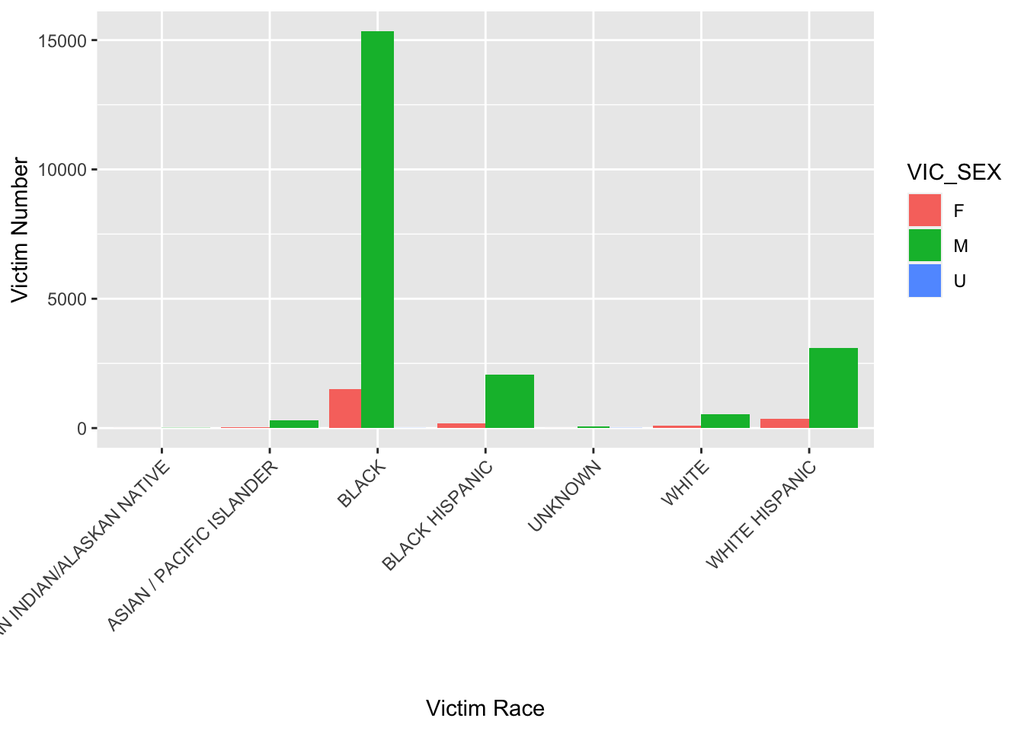

```r
  ggplot(visual1, aes(x = VIC_RACE, y = count, fill = VIC_SEX)) +
    geom_bar(position = "dodge", stat = "identity") +
    theme(axis.text.x = element_text(angle = 45, vjust = 1, hjust = 1)) +
    labs(x = "Victim Race", y = "Victim Number")
```

*Analysis 1:*

Based on the graph above, the number of unknown race and unknown gender are at low frequency which are negligible, so the numbers of cases are reliable for analysis. As noticed, for all races, the male victims are more than the female victims. Also, for all races, mostly the victims are Black people, followed by White Hispanic, black Hispanic, White, Asian/Pacific Islander and lastly are American Indian/Alaskan natives.

**Visualization 2: relationship between Incident Occur Time(by hours) and Borough where shooting occurred**

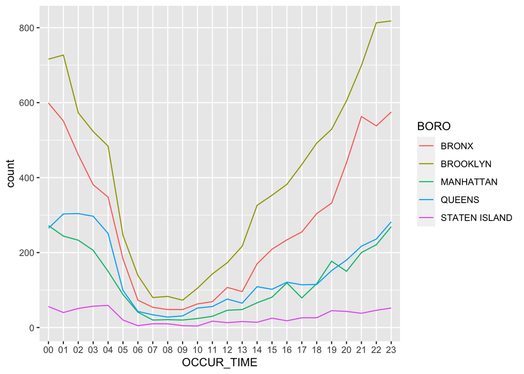

```r
visual2 <- data1 %>%
  mutate(OCCUR_TIME = format(as.POSIXct(OCCUR_TIME), format = "%H")) %>%
  group_by(OCCUR_TIME,BORO) %>%
  summarise(count = n()) %>%
  ungroup()

  ggplot(visual2,aes(x = OCCUR_TIME, y = count, group = BORO, color = BORO)) +
    geom_line()
```

*Analysis 2:*

According to this plot, it’s obvious that between 4AM to 9AM, the shooting incident went down and especially during the morning, the shooting incidents were lowest in a day for all boroughs. While the incidents in Staten Island is approximately steady when the hours changed, the range of incidents by hours in Brooklyn is the widest. There’s another interesting result from this plot, that is, the incidents has a curve in Queens while in other boroughs are dropped during the time from 12AM to 4AM.

**Model: logistic regression model**

```r
data$BORO <- as.factor(data$BORO)
data$VIC_AGE_GROUP <- as.factor(data$VIC_AGE_GROUP)
mod <- data %>%
  mutate(STATISTICAL_MURDER_FLAG = ifelse(STATISTICAL_MURDER_FLAG == "TRUE", 1, 0))

model <- glm(STATISTICAL_MURDER_FLAG ~ BORO + VIC_AGE_GROUP, data = mod,
    family = binomial(link = "logit"))
summary(model)
```

```
##
## Call:
## glm(formula = STATISTICAL_MURDER_FLAG ~ BORO + VIC_AGE_GROUP,
##     family = binomial(link = "logit"), data = mod)
##
## Deviance Residuals:
##     Min       1Q   Median       3Q      Max
## -0.9358  -0.7100  -0.6022  -0.5267   2.0722
##
## Coefficients:
##                      Estimate Std. Error z value Pr(>|z|)
## (Intercept)          -1.94168    0.06502 -29.865  < 2e-16 ***
## BOROBROOKLYN          0.03658    0.04071   0.899  0.36892
## BOROMANHATTAN        -0.08116    0.05810  -1.397  0.16246
## BOROQUEENS            0.04249    0.05295   0.803  0.42224
## BOROSTATEN ISLAND     0.09393    0.09951   0.944  0.34523
## VIC_AGE_GROUP18-24    0.28949    0.06632   4.365 1.27e-05 ***
## VIC_AGE_GROUP25-44    0.65554    0.06445  10.172  < 2e-16 ***
## VIC_AGE_GROUP45-64    0.84340    0.08379  10.066  < 2e-16 ***
## VIC_AGE_GROUP65+      1.24884    0.18067   6.912 4.77e-12 ***
## VIC_AGE_GROUPUNKNOWN  0.84647    0.30498   2.775  0.00551 **
## ---
## Signif. codes:  0 '***' 0.001 '**' 0.01 '*' 0.05 '.' 0.1 ' ' 1
##
## (Dispersion parameter for binomial family taken to be 1)
##
##     Null deviance: 22990  on 23584  degrees of freedom
## Residual deviance: 22755  on 23575  degrees of freedom
## AIC: 22775
##
## Number of Fisher Scoring iterations: 4
```

*Analysis of this model:*

The baseline of BORO is BRONX, other boroughs all have a p-value greater than 0.05, which means borough is not statistically significant in this model. The baseline of Victims Age Range is less than 18, since the coefficient of group 65+ is 1.24884 which is greater than 0 and is the greatest than other groups with a p-value smaller than 0.05, then the log odds of victim age >65 is greater than <18 and other age groups. As the age increases the log odds of victims being murdered also increased.

*Bias:* For sources of bias, black people is the primary race in this data set, so I think this data set might be bias, and the number of victims between black and other races should not be that much different. Personally, I assumed that the number of female victims is larger than male victims, because when the situation is chaotic, the female might run slower than male. However, according to my first visualization, it turned out that the number of male victims is way more than female.